# Online Shop Analysis

## Specifying The Question

To assist the sales team in identifying characteristics of consumer groups, do cluster analysis on customer behavior data obtained by Kira Plastinina, a Russian company.

## Metrics of success

Distinction of customer groups and their differentiating characteristics.

## Understanding the context

We will be using data collected from an E-Commerce site. E-commerce is the buying and selling of goods and services, or the transmitting of funds or data, over an electronic network, primarily the internet.

Kira Plastinina is a Russian brand that is sold through a defunct chain of retail stores in Russia, Ukraine, Kazakhstan, Belarus, China, Philippines, and Armenia. The brand’s Sales and Marketing team would like to understand their customer’s behavior from data that they have collected over the past year. More specifically, they would like to learn the characteristics of customer groups.

## Recording the experimental design

- Loading the data
- Check the Data
- Perform Data Cleaning
- Perform Exploratory Data Analysis (Univariate, Bivariate & Multivariate)
- Implement the Solution
- Conclusion

### Loading libraries

```r
# Importing the necessary R libraries
library(tidyverse)
library(magrittr)
```

```r
library(corrplot)
library(caret)
library(readr)
library(BBmisc)
library(psych)
options(warn = -1)

library(grid)
theme_set(theme_bw())
options(warn = -1)
```

```r
library(ggplot2)
```

### Loading data

```r
shop = read.csv("http://bit.ly/EcommerceCustomersDataset")
```

## Exploratory Analysis

### Checking the data

```r
# checking the head of our data
head(shop)
```

|  | Administrative | Administrative_Duration | Informational | Informational_Duration | ProductRelated | ProductRelated_Duration | BounceRates | ExitRates | PageValues | SpecialDay | Month | OperatingSystems | Browser | Region | TrafficType | VisitorType | Weekend | Revenue |
| --- | --- | --- | --- | --- | --- | --- | --- | --- | --- | --- | --- | --- | --- | --- | --- | --- | --- | --- |
| 1 | 0 | 0 | 0 | 0 | 1 | 0.000000 | 0.20000000 | 0.2000000 | 0 | 0 | Feb | 1 | 1 | 1 | 1 | Returning_Visitor | FALSE | FALSE |
| 2 | 0 | 0 | 0 | 0 | 2 | 64.000000 | 0.00000000 | 0.1000000 | 0 | 0 | Feb | 2 | 2 | 1 | 2 | Returning_Visitor | FALSE | FALSE |
| 3 | 0 | -1 | 0 | -1 | 1 | -1.000000 | 0.20000000 | 0.2000000 | 0 | 0 | Feb | 4 | 1 | 9 | 3 | Returning_Visitor | FALSE | FALSE |
| 4 | 0 | 0 | 0 | 0 | 2 | 2.666667 | 0.05000000 | 0.1400000 | 0 | 0 | Feb | 3 | 2 | 2 | 4 | Returning_Visitor | FALSE | FALSE |
| 5 | 0 | 0 | 0 | 0 | 10 | 627.500000 | 0.02000000 | 0.0500000 | 0 | 0 | Feb | 3 | 3 | 1 | 4 | Returning_Visitor | TRUE | FALSE |
| 6 | 0 | 0 | 0 | 0 | 19 | 154.216667 | 0.01578947 | 0.0245614 | 0 | 0 | Feb | 2 | 2 | 1 | 3 | Returning_Visitor | FALSE | FALSE |

```r
# checking the tail of our data
tail(shop)
```

|  | Administrative | Administrative_Duration | Informational | Informational_Duration | ProductRelated | ProductRelated_Duration | BounceRates | ExitRates | PageValues | SpecialDay | Month | OperatingSystems | Browser | Region | TrafficType | VisitorType | Weekend | Revenue |
| --- | --- | --- | --- | --- | --- | --- | --- | --- | --- | --- | --- | --- | --- | --- | --- | --- | --- | --- |
| 12325 | 0 | 0 | 1 | 0 | 16 | 503.000 | 0.000000000 | 0.03764706 | 0.00000 | 0 | Nov | 2 | 2 | 1 | 1 | Returning_Visitor | FALSE | FALSE |
| 12326 | 3 | 145 | 0 | 0 | 53 | 1783.792 | 0.007142857 | 0.02903061 | 12.24172 | 0 | Dec | 4 | 6 | 1 | 1 | Returning_Visitor | TRUE | FALSE |
| 12327 | 0 | 0 | 0 | 0 | 5 | 465.750 | 0.000000000 | 0.02133333 | 0.00000 | 0 | Nov | 3 | 2 | 1 | 8 | Returning_Visitor | TRUE | FALSE |
| 12328 | 0 | 0 | 0 | 0 | 6 | 184.250 | 0.083333333 | 0.08666667 | 0.00000 | 0 | Nov | 3 | 2 | 1 | 13 | Returning_Visitor | TRUE | FALSE |
| 12329 | 4 | 75 | 0 | 0 | 15 | 346.000 | 0.000000000 | 0.02105263 | 0.00000 | 0 | Nov | 2 | 2 | 3 | 11 | Returning_Visitor | FALSE | FALSE |
| 12330 | 0 | 0 | 0 | 0 | 3 | 21.250 | 0.000000000 | 0.06666667 | 0.00000 | 0 | Nov | 3 | 2 | 1 | 2 | New_Visitor | TRUE | FALSE |

```r
# checking the structure of the data
str(shop)
```

```
## 'data.frame':    12330 obs. of  18 variables:
##  $ Administrative         : int  0 0 0 0 0 0 0 1 0 0 ...
##  $ Administrative_Duration: num  0 0 -1 0 0 0 -1 -1 0 0 ...
##  $ Informational          : int  0 0 0 0 0 0 0 0 0 0 ...
##  $ Informational_Duration : num  0 0 -1 0 0 0 -1 -1 0 0 ...
##  $ ProductRelated         : int  1 2 1 2 10 19 1 1 2 3 ...
##  $ ProductRelated_Duration: num  0 64 -1 2.67 627.5 ...
##  $ BounceRates            : num  0.2 0 0.2 0.05 0.02 ...
##  $ ExitRates              : num  0.2 0.1 0.2 0.14 0.05 ...
##  $ PageValues             : num  0 0 0 0 0 0 0 0 0 0 ...
##  $ SpecialDay             : num  0 0 0 0 0 0 0.4 0 0.8 0.4 ...
##  $ Month                  : chr  "Feb" "Feb" "Feb" "Feb" ...
##  $ OperatingSystems       : int  1 2 4 3 3 2 2 1 2 2 ...
##  $ Browser                : int  1 2 1 2 3 2 4 2 2 4 ...
##  $ Region                 : int  1 1 9 2 1 1 3 1 2 1 ...
##  $ TrafficType            : int  1 2 3 4 4 3 3 5 3 2 ...
##  $ VisitorType            : chr  "Returning_Visitor" "Returning_Visitor" "Returning_Visitor" "Returning_Visitor" ...
##  $ Weekend                : logi  FALSE FALSE FALSE FALSE TRUE FALSE ...
##  $ Revenue                : logi  FALSE FALSE FALSE FALSE FALSE FALSE ...
```

The dataset consists of 10 numerical and 8 categorical attributes

```r
# checking the number of observations and features
dim(shop)
```

```
## [1] 12330    18
```

Our data set has 12330 observations and 18 variables.

### Tidying the data

```r
# Checking for missing values
colSums(is.na(shop))
```

```
##          Administrative Administrative_Duration           Informational
##                      14                      14                      14
##  Informational_Duration          ProductRelated ProductRelated_Duration
##                      14                      14                      14
##             BounceRates               ExitRates              PageValues
##                      14                      14                       0
##              SpecialDay                   Month        OperatingSystems
##                       0                       0                       0
##                 Browser                  Region             TrafficType
##                       0                       0                       0
##             VisitorType                 Weekend                 Revenue
##                       0                       0                       0
```

There are missing values in the columns: Administrative, Administrative_Duration,Informationa,Informational_Duration,ProductRelated,ProductRelated_Duration,BounceRates,ExitRates.

Let’s check whether the features (columns) and samples (rows) have more than 5% of the data missing using a function.

```r
pMiss <- function(x){sum(is.na(x))/length(x)*100}
apply(shop,2,pMiss)
```

```
##          Administrative Administrative_Duration           Informational
##               0.1135442               0.1135442               0.1135442
##  Informational_Duration          ProductRelated ProductRelated_Duration
##               0.1135442               0.1135442               0.1135442
##             BounceRates               ExitRates              PageValues
##               0.1135442               0.1135442               0.0000000
##              SpecialDay                   Month        OperatingSystems
##               0.0000000               0.0000000               0.0000000
##                 Browser                  Region             TrafficType
##               0.0000000               0.0000000               0.0000000
##             VisitorType                 Weekend                 Revenue
##               0.0000000               0.0000000               0.0000000
```

```r
apply(shop,1,pMiss)
```

[output not shown]

[output cut: 1527 more lines]

```r
# Omitting missing values
shop = na.omit(shop)

# Checking for missing values

colSums(is.na(shop))
```

```
##          Administrative Administrative_Duration           Informational
##                       0                       0                       0
##  Informational_Duration          ProductRelated ProductRelated_Duration
##                       0                       0                       0
##             BounceRates               ExitRates              PageValues
##                       0                       0                       0
##              SpecialDay                   Month        OperatingSystems
##                       0                       0                       0
##                 Browser                  Region             TrafficType
##                       0                       0                       0
##             VisitorType                 Weekend                 Revenue
##                       0                       0                       0
```

```r
# Check for number of remaining columns
print("The number of rows is:",quote=FALSE)
```

```
## [1] The number of rows is:
```

```r
nrow(shop)
```

```
## [1] 12316
```

The missing values have been omitted and we now have 12316 observations which is enough for our analysis.

```r
# Checking for duplicates
duplicates <- shop[duplicated(shop),]
dim(duplicates)
```

```
## [1] 117  18
```

There are 117 duplicates rows. We will remove the duplicates so as to have reliable data.

```r
# removing duplicates
shop <- shop[!duplicated(shop),]
dim(shop)
```

```
## [1] 12199    18
```

We now have 12199 observations and 18 variables.Our data set seems to still be enough for the analysis.

```r
# Check for unique values in month and visitor type columns
unique(shop$Month);
```

```
##  [1] "Feb"  "Mar"  "May"  "Oct"  "June" "Jul"  "Aug"  "Nov"  "Sep"  "Dec"
```

```r
unique(shop$VisitorType);
```

```
## [1] "Returning_Visitor" "New_Visitor"       "Other"
```

- The unique values seem okay.
- The visitor type has 3 unique values; Returning visitor, New visitor and other.
- The months;Jan and April have no record.

#### There appears to be anomalies in the ProductRelated_Duration, Administrative_Duration and Informational_Duration columns with some observations having a value of -1. Duration cannot be negative.

```r
# Check the number of records with this anomaly

anomaly <- shop %>% select(c(Administrative_Duration, Administrative, Informational_Duration, Informational, ProductRelated_Duration, ProductRelated)) %>% filter(Administrative_Duration == -1 | Informational_Duration == -1 | ProductRelated_Duration == -1)

anomaly
```

| Administrative_Duration | Administrative | Informational_Duration | Informational | ProductRelated_Duration | ProductRelated |
| --- | --- | --- | --- | --- | --- |
| -1 | 0 | -1 | 0 | -1 | 1 |
| -1 | 0 | -1 | 0 | -1 | 1 |
| -1 | 1 | -1 | 0 | -1 | 1 |
| -1 | 0 | -1 | 0 | -1 | 1 |
| -1 | 0 | -1 | 0 | -1 | 1 |
| -1 | 0 | -1 | 0 | -1 | 1 |
| -1 | 0 | -1 | 0 | -1 | 1 |
| -1 | 0 | -1 | 0 | -1 | 1 |
| -1 | 0 | -1 | 0 | -1 | 1 |
| -1 | 0 | -1 | 0 | -1 | 1 |

[output cut: 23 more lines]

There are 33 records with this anomaly. We will drop this records.

```r
# Dropping the 33 records
shop <- shop %>% filter(Administrative_Duration != -1, Informational_Duration != -1, ProductRelated_Duration != 1)
```

```r
# checking the remaining observations in our data
dim(shop)
```

```
## [1] 12164    18
```

Our data has 12164 observations now. This is still good for our analysis.

```r
# Creating a  function to check for the number of outliers in each column

outlier_detector <- function(x){
  out <- boxplot.stats(x)$out
  return((length(out)/  12164)*100)
}
```

```r
# Get outlier count per column
sapply(shop[,c(1:9)], outlier_detector)
```

```
##          Administrative Administrative_Duration           Informational
##                3.321276                9.363696               21.621177
##  Informational_Duration          ProductRelated ProductRelated_Duration
##               19.763236                8.278527                7.809931
##             BounceRates               ExitRates              PageValues
##               11.649129               10.637948               22.443275
```

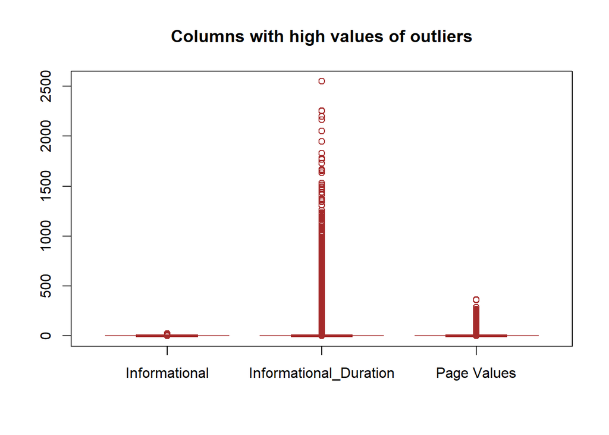

```r
# Plot boxplots of columns with high % of outliers
boxplot(shop$Informational, shop$Informational_Duration, shop$PageValues,
main = "Columns with high values of outliers",
names = c("Informational", "Informational_Duration", "Page Values"),
col = c("orange","blue"),
border = "brown",
notch = TRUE)
```

- All outliers are found above the third quantile, implying that they are all found in the higher ranges of the above variables. Given the nature of the data, it’s quite possible for customers to spend extended periods of time on informational pages or browsing pages containing high-value items. As a result, we will keep the outliers.
- The other outliers will not be removed because they may reveal information about certain special days or consumers.

### Univariate Analysis

When using univariate approaches, you just look at one variable at a time.

The following are examples of univariate analysis:

- Mean, Median, and Mode are three measures of central tendancy.
- Dispersion measures include the minimum, maximum, range, quartiles, variance, and standard deviation.
- Other factors to consider are skewness and kurtosis.
- Histogram, Box plots, Bar plots, and Kernel density plots are examples of univariate graphs.

```r
# checking the summary statistics of each column
summary(shop)
```

```
##  Administrative   Administrative_Duration Informational
##  Min.   : 0.000   Min.   :   0.00         Min.   : 0.0000
##  1st Qu.: 0.000   1st Qu.:   0.00         1st Qu.: 0.0000
##  Median : 1.000   Median :  10.00         Median : 0.0000
##  Mean   : 2.347   Mean   :  81.92         Mean   : 0.5103
##  3rd Qu.: 4.000   3rd Qu.:  95.00         3rd Qu.: 0.0000
##  Max.   :27.000   Max.   :3398.75         Max.   :24.0000
##  Informational_Duration ProductRelated   ProductRelated_Duration
##  Min.   :   0.00        Min.   :  0.00   Min.   :    0.0
##  1st Qu.:   0.00        1st Qu.:  8.00   1st Qu.:  196.5
##  Median :   0.00        Median : 18.00   Median :  613.2
##  Mean   :  34.94        Mean   : 32.15   Mean   : 1211.0
##  3rd Qu.:   0.00        3rd Qu.: 38.00   3rd Qu.: 1482.0
##  Max.   :2549.38        Max.   :705.00   Max.   :63973.5
##   BounceRates         ExitRates         PageValues       SpecialDay
##  Min.   :0.000000   Min.   :0.00000   Min.   :  0.00   Min.   :0.00000
##  1st Qu.:0.000000   1st Qu.:0.01417   1st Qu.:  0.00   1st Qu.:0.00000
##  Median :0.002865   Median :0.02500   Median :  0.00   Median :0.00000
##  Mean   :0.020001   Mean   :0.04108   Mean   :  5.97   Mean   :0.06202
##  3rd Qu.:0.016318   3rd Qu.:0.04804   3rd Qu.:  0.00   3rd Qu.:0.00000
##  Max.   :0.200000   Max.   :0.20000   Max.   :361.76   Max.   :1.00000
##     Month           OperatingSystems    Browser           Region
##  Length:12164       Min.   :1.000    Min.   : 1.000   Min.   :1.000
##  Class :character   1st Qu.:2.000    1st Qu.: 2.000   1st Qu.:1.000
##  Mode  :character   Median :2.000    Median : 2.000   Median :3.000
##                     Mean   :2.125    Mean   : 2.358   Mean   :3.153
##                     3rd Qu.:3.000    3rd Qu.: 2.000   3rd Qu.:4.000
##                     Max.   :8.000    Max.   :13.000   Max.   :9.000
##   TrafficType     VisitorType         Weekend         Revenue
##  Min.   : 1.000   Length:12164       Mode :logical   Mode :logical
##  1st Qu.: 2.000   Class :character   FALSE:9311      FALSE:10256
##  Median : 2.000   Mode  :character   TRUE :2853      TRUE :1908
##  Mean   : 4.076
##  3rd Qu.: 4.000
##  Max.   :20.000
```

The method describe() gives more measures of dispersion compared to the summary()

- Number of rows
- Standard deviation
- Trimmed mean
- Mean absolute deviation
- Skewness
- Kurtosis
- Standard error

```r
# describing our columns
describe(shop)
```

|  | vars | n | mean | sd | median | trimmed | mad | min | max | range | skew | kurtosis | se |
| --- | --- | --- | --- | --- | --- | --- | --- | --- | --- | --- | --- | --- | --- |
| Administrative | 1 | 12164 | 2.346597e+00 | 3.333362e+00 | 1.000000e+00 | 1.663481e+00 | 1.482600e+00 | 0 | 27.0000 | 27.0000 | 1.9422398 | 4.6177852 | 3.022346e-02 |
| Administrative_Duration | 2 | 12164 | 8.191988e+01 | 1.777280e+02 | 1.000000e+01 | 4.306466e+01 | 1.482600e+01 | 0 | 3398.7500 | 3398.7500 | 5.5829957 | 49.9688835 | 1.611453e+00 |
| Informational | 3 | 12164 | 5.102762e-01 | 1.277359e+00 | 0.000000e+00 | 1.836210e-01 | 0.000000e+00 | 0 | 24.0000 | 24.0000 | 4.0066920 | 26.5612540 | 1.158177e-02 |
| Informational_Duration | 4 | 12164 | 3.494029e+01 | 1.416488e+02 | 0.000000e+00 | 3.760896e+00 | 0.000000e+00 | 0 | 2549.3750 | 2549.3750 | 7.5256309 | 75.2330226 | 1.284325e+00 |
| ProductRelated | 5 | 12164 | 3.214765e+01 | 4.463397e+01 | 1.800000e+01 | 2.313738e+01 | 1.927380e+01 | 0 | 705.0000 | 705.0000 | 4.3293877 | 31.0050480 | 4.046945e-01 |
| ProductRelated_Duration | 6 | 12164 | 1.210985e+03 | 1.921592e+03 | 6.132431e+02 | 8.355864e+02 | 7.475908e+02 | 0 | 63973.5222 | 63973.5222 | 7.2477856 | 136.4323050 | 1.742300e+01 |
| BounceRates | 7 | 12164 | 2.000135e-02 | 4.456924e-02 | 2.865353e-03 | 8.016036e-03 | 4.248172e-03 | 0 | 0.2000 | 0.2000 | 3.2096344 | 9.7080242 | 4.041076e-04 |
| ExitRates | 8 | 12164 | 4.108456e-02 | 4.562299e-02 | 2.500000e-02 | 3.108369e-02 | 2.059167e-02 | 0 | 0.2000 | 0.2000 | 2.2550839 | 4.7918596 | 4.136620e-04 |
| PageValues | 9 | 12164 | 5.969628e+00 | 1.868188e+01 | 0.000000e+00 | 1.341850e+00 | 0.000000e+00 | 0 | 361.7637 | 361.7637 | 6.3388961 | 64.7506568 | 1.693879e-01 |
| SpecialDay | 10 | 12164 | 6.201907e-02 | 1.998299e-01 | 0.000000e+00 | 6.165228e-04 | 0.000000e+00 | 0 | 1.0000 | 1.0000 | 3.2833994 | 9.7777365 | 1.811850e-03 |

[output cut: 8 more lines]

Informational Duration, ProductRelated Duration, and PageValues are the most positively skewed variables, having high kurtosis values.

```r
# Frequency distribution of the categorical variables
sapply(shop[, c(11:18)], table)
```

```
## $Month
##
##  Aug  Dec  Feb  Jul June  Mar  May  Nov  Oct  Sep
##  433 1706  169  431  285 1842 3321 2980  549  448
##
## $OperatingSystems
##
##    1    2    3    4    5    6    7    8
## 2539 6519 2523  476    6   19    7   75
##
## $Browser
##
##    1    2    3    4    5    6    7    8    9   10   11   12   13
## 2418 7859  104  727  464  174   49  134    1  162    6   10   56
##
## $Region
##
##    1    2    3    4    5    6    7    8    9
## 4701 1122 2374 1164  315  800  755  431  502
##
## $TrafficType
##
##    1    2    3    4    5    6    7    8    9   10   11   12   13   14   15   16
## 2373 3905 2002 1064  259  440   40  343   41  450  247    1  727   13   36    3
##   17   18   19   20
##    1   10   17  192
##
## $VisitorType
##
##       New_Visitor             Other Returning_Visitor
##              1693                81             10390
##
## $Weekend
##
## FALSE  TRUE
##  9311  2853
##
## $Revenue
##
## FALSE  TRUE
## 10256  1908
```

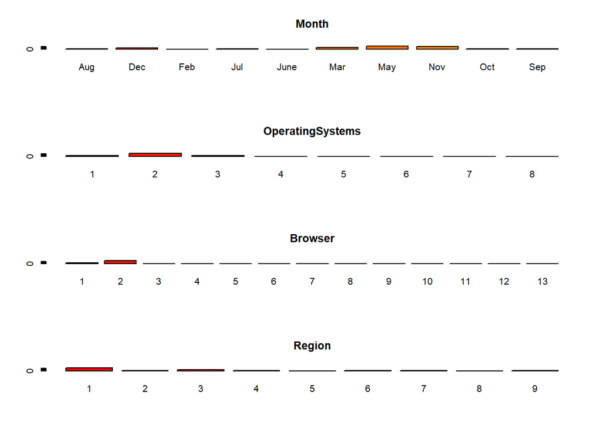

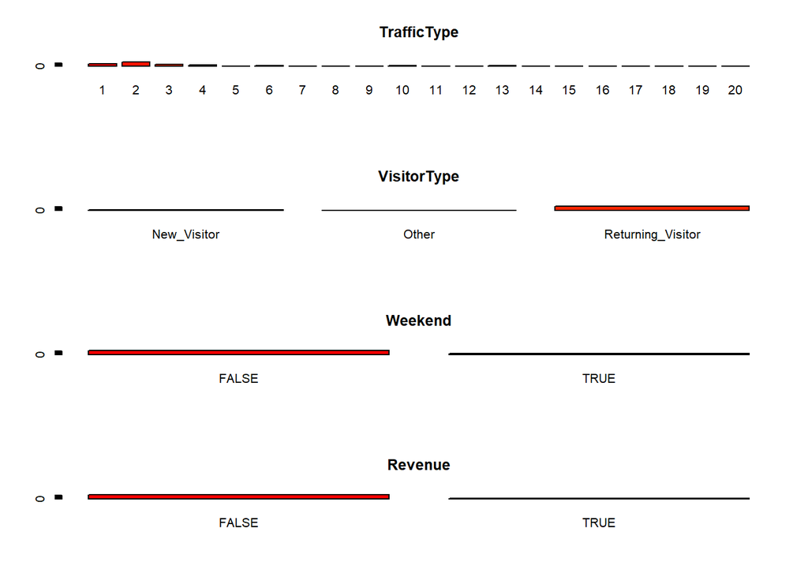

```r
# Creating histogram plots to visually view the categorical variables
par(mfrow=c(4,1))
for(i in 11:18) {
    counts <- table(shop[,i])
    name <- names(shop)[i]
    barplot(counts, main=name, col = heat.colors(20))}
```

### Bivariate Analysis

Two variables are analyzed to see if there is a relationship between them.

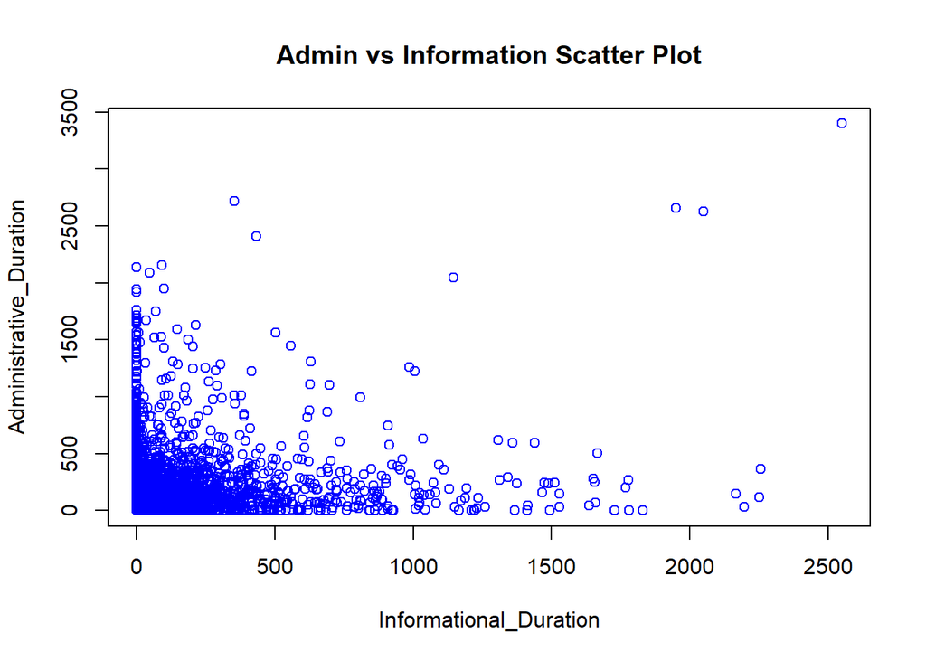

```r
# Let's plot scatter plots
plot(Administrative_Duration ~ Informational_Duration, dat = shop,
      col = "blue",
      main = "Admin vs Information Scatter Plot")
```

The Administration duration and Information duration seem to have a weak relationship.

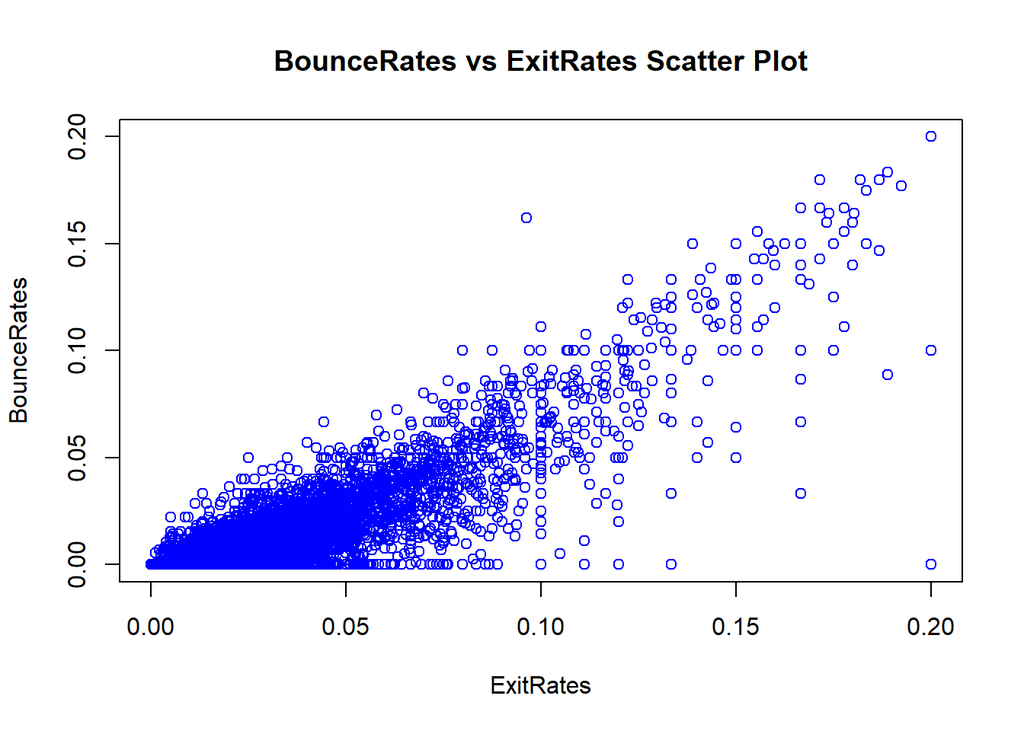

```r
# Let's plot scatter plots
plot(BounceRates ~ ExitRates, dat = shop,
      col = "blue",
      main = "BounceRates vs ExitRates Scatter Plot")
```

There is a high positive correlation between Bounce and exit rates. This shows that users who bounce from one page to another are most likely to exit the site quicker.

```r
# Number of visits to product related pages per month
product_stats <- shop %>% select(ProductRelated, ProductRelated_Duration, Month)%>%group_by(Month)%>% summarise_all(mean)
product_stats[order(product_stats$ProductRelated, decreasing = TRUE),]
```

| Month | ProductRelated | ProductRelated_Duration |
| --- | --- | --- |
| Nov | 46.31074 | 1769.0191 |
| Aug | 38.25866 | 1272.6537 |
| Jul | 36.48724 | 1220.4291 |
| June | 36.43509 | 1226.1500 |
| Oct | 33.56648 | 1116.9777 |
| Sep | 33.10491 | 1253.3882 |
| Dec | 28.32708 | 1125.1524 |
| May | 26.81542 | 994.6053 |
| Mar | 20.45603 | 840.5158 |
| Feb | 12.08876 | 512.8207 |

It seems that there is more activity in November as it has the highest product related visits and the product related duration is high as well.

```r
# Getting the  bounce rates and exit rates among visitor groups
visitor <- shop %>% select(VisitorType, ExitRates, BounceRates)%>% group_by(VisitorType)%>%summarise_all(mean)

visitor
```

| VisitorType | ExitRates | BounceRates |
| --- | --- | --- |
| New_Visitor | 0.02057460 | 0.005146133 |
| Other | 0.05660046 | 0.030578592 |
| Returning_Visitor | 0.04430560 | 0.022339472 |

Visitors of type other have a higher ExitRate and BounceRates followed by ReturningVisitors.

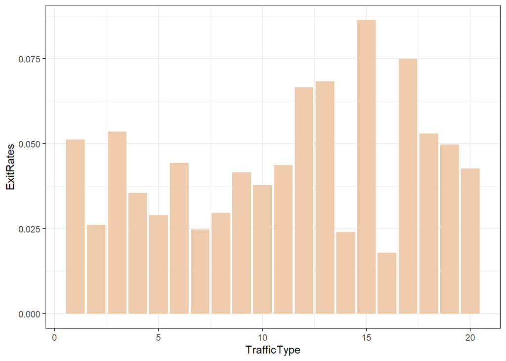

```r
# Creating a plot to show the ExitRate and BounceRatesin relation to the traffic type.
traffic <- shop %>% select(TrafficType, ExitRates, BounceRates)%>% group_by(TrafficType)%>% summarise_all(mean)
par(mfrow = c(1,2))
ggplot(traffic, aes(x=TrafficType, y = ExitRates))+
  geom_bar(stat = "identity", fill="peachpuff2")
```

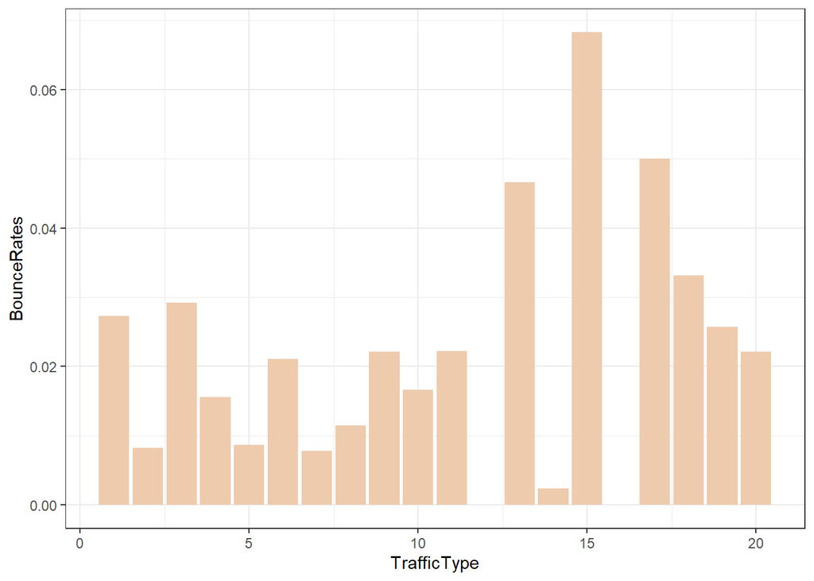

```r
ggplot(traffic, aes(x=TrafficType, y = BounceRates))+
  geom_bar(stat = "identity", fill="peachpuff2")
```

The traffic types 15 and 17 have the highest Exit and Bounce Rates.

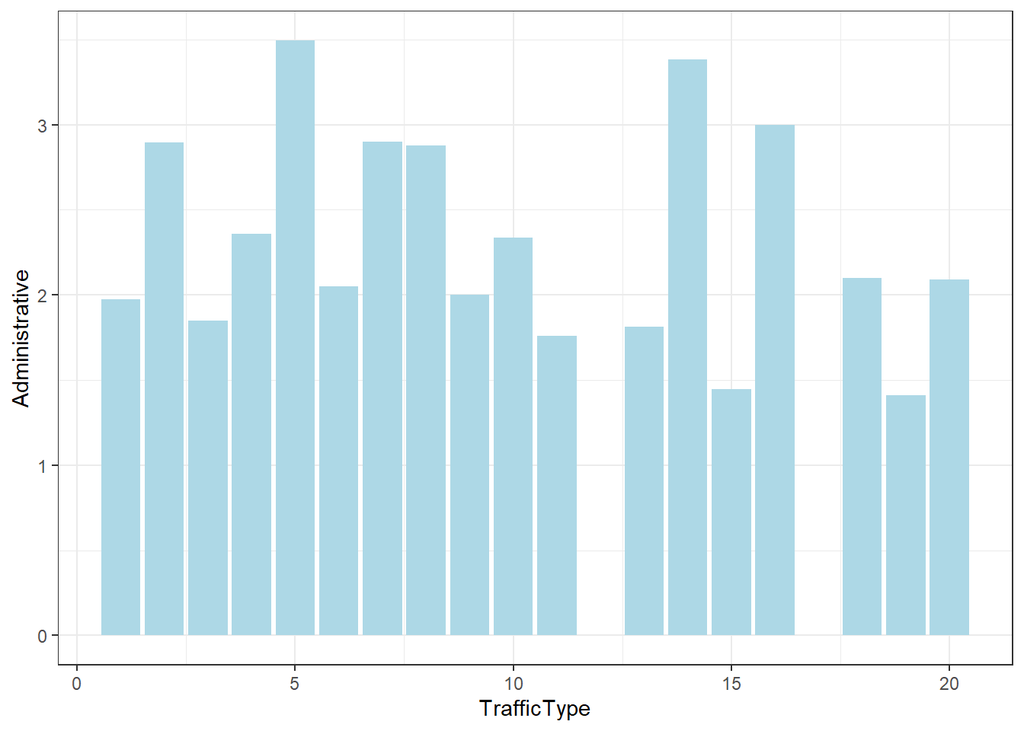

```r
# Creating a plot to show the Administrative, ProductRelated and Informational relation to the traffic type.
traffic_page<- shop %>% select(TrafficType, Administrative,Informational,ProductRelated)%>% group_by(TrafficType)%>% summarise_all(mean)
par(mfrow = c(1,3))
ggplot(traffic_page, aes(x=TrafficType, y = Administrative))+
  geom_bar(stat = "identity", fill="lightblue")
```

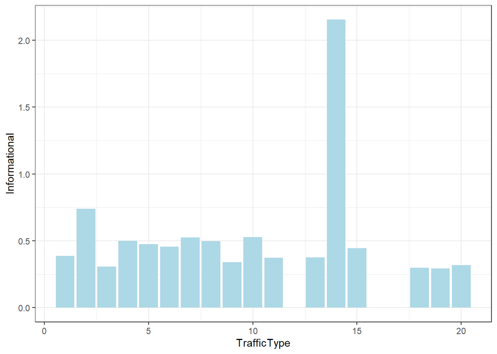

```r
ggplot(traffic_page, aes(x=TrafficType, y = Informational))+
  geom_bar(stat = "identity", fill="lightblue")
```

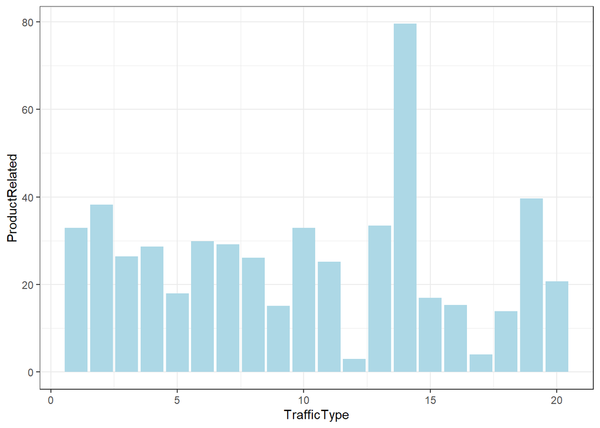

```r
ggplot(traffic_page, aes(x=TrafficType, y = ProductRelated))+
  geom_bar(stat = "identity", fill="lightblue")
```

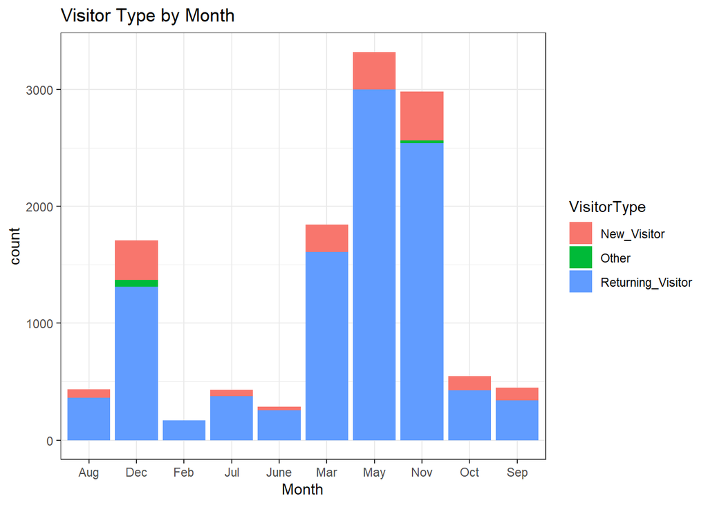

```r
# Stacked bar chart: Visitor Type vs Month
shop %>%
    ggplot(aes(Month)) +
    geom_bar(aes(fill = VisitorType))+
    labs(title = "Visitor Type by Month")
```

- Feb and June are the least busy months.
- May, Nov, March, and December are the busy months.
- During these months there is a higher number of new visitors. This can be leveraged by the company to create advertisements that will attract the new users to register to the site.
- **Other** customer shops in November and December.

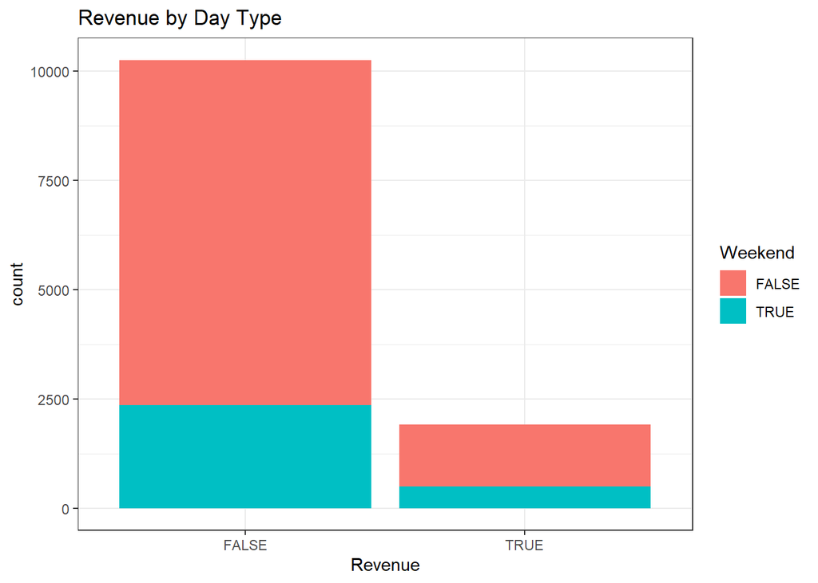

```r
# Stacked bar chart: Revenue vs Day Type
shop %>%
    ggplot(aes(Revenue)) +
    geom_bar(aes(fill = Weekend))+
    labs(title = "Revenue by Day Type")
```

- Our data is imbalanced.
- Most of the data indicates that a client’s visit to the page did not result in income for the company, i.e. the customer did not make a purchase.
- Of the remaining data, the company made revenue mostly during the weekdays.

### Multivariate Analysis

Three or more variables are analyzed to derive conclusions and find relationships between them.

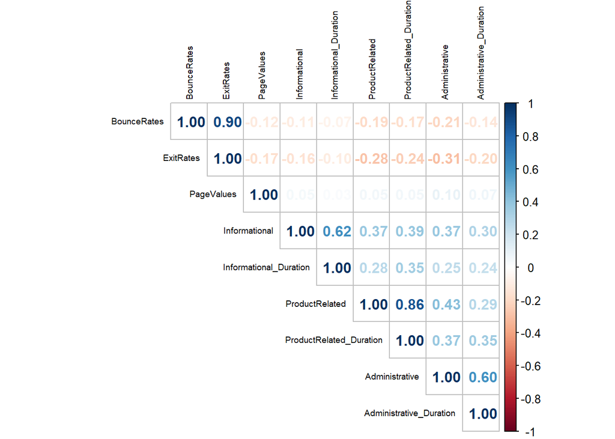

```r
# calculating correlations and plotting a correlation plot
corrplot(corr = cor(shop[, c(1:9)]), method = "number", type = "upper", order = "hclust", tl.col = "black", tl.cex = 0.6)
```

There is a high correlation between bounce rates and exit rates.

## Implementing the solution

### Encoding our categorical variables

```r
# One hot encoding of the factor/categorical variables.

dummy_shop = dummyVars(" ~ .", data = shop)

df = data.frame(predict(dummy_shop, newdata = shop))
```

```r
# checking the data types
sapply(df, class)
```

```
##               Administrative      Administrative_Duration
##                    "numeric"                    "numeric"
##                Informational       Informational_Duration
##                    "numeric"                    "numeric"
##               ProductRelated      ProductRelated_Duration
##                    "numeric"                    "numeric"
##                  BounceRates                    ExitRates
##                    "numeric"                    "numeric"
##                   PageValues                   SpecialDay
##                    "numeric"                    "numeric"
##                     MonthAug                     MonthDec
##                    "numeric"                    "numeric"
##                     MonthFeb                     MonthJul
##                    "numeric"                    "numeric"
##                    MonthJune                     MonthMar
##                    "numeric"                    "numeric"
##                     MonthMay                     MonthNov
##                    "numeric"                    "numeric"
##                     MonthOct                     MonthSep
##                    "numeric"                    "numeric"
##             OperatingSystems                      Browser
##                    "numeric"                    "numeric"
##                       Region                  TrafficType
##                    "numeric"                    "numeric"
##       VisitorTypeNew_Visitor             VisitorTypeOther
##                    "numeric"                    "numeric"
## VisitorTypeReturning_Visitor                 WeekendFALSE
##                    "numeric"                    "numeric"
##                  WeekendTRUE                 RevenueFALSE
##                    "numeric"                    "numeric"
##                  RevenueTRUE
##                    "numeric"
```

```r
glimpse(df)
```

```
## Rows: 12,164
## Columns: 31
## $ Administrative               <dbl> 0, 0, 0, 0, 0, 0, 0, 0, 0, 0, 0, 0, 2, 0,~
## $ Administrative_Duration      <dbl> 0.0, 0.0, 0.0, 0.0, 0.0, 0.0, 0.0, 0.0, 0~
## $ Informational                <dbl> 0, 0, 0, 0, 0, 0, 0, 0, 0, 0, 0, 0, 0, 0,~
## $ Informational_Duration       <dbl> 0, 0, 0, 0, 0, 0, 0, 0, 0, 0, 0, 0, 0, 0,~
## $ ProductRelated               <dbl> 1, 2, 2, 10, 19, 2, 3, 3, 16, 7, 6, 2, 23~
## $ ProductRelated_Duration      <dbl> 0.000000, 64.000000, 2.666667, 627.500000~
## $ BounceRates                  <dbl> 0.200000000, 0.000000000, 0.050000000, 0.~
## $ ExitRates                    <dbl> 0.200000000, 0.100000000, 0.140000000, 0.~
## $ PageValues                   <dbl> 0.00000, 0.00000, 0.00000, 0.00000, 0.000~
## $ SpecialDay                   <dbl> 0.0, 0.0, 0.0, 0.0, 0.0, 0.8, 0.4, 0.0, 0~
## $ MonthAug                     <dbl> 0, 0, 0, 0, 0, 0, 0, 0, 0, 0, 0, 0, 0, 0,~
## $ MonthDec                     <dbl> 0, 0, 0, 0, 0, 0, 0, 0, 0, 0, 0, 0, 0, 0,~
## $ MonthFeb                     <dbl> 1, 1, 1, 1, 1, 1, 1, 1, 1, 1, 1, 1, 1, 1,~
```

[output cut: 18 more lines]

```r
# We will remove the Revenue column it is the class label, we will store it in another variable
df_copy <- df[, -c(30:31)]
df.class<- shop[, "Revenue"]

df_copy_copy <- df[, -c(30,31)]
```

```r
# Previewing the dataset with dummies
head(df_copy)
```

|  | Administrative | Administrative_Duration | Informational | Informational_Duration | ProductRelated | ProductRelated_Duration | BounceRates | ExitRates | PageValues | SpecialDay | MonthAug | MonthDec | MonthFeb | MonthJul | MonthJune | MonthMar | MonthMay | MonthNov | MonthOct | MonthSep | OperatingSystems | Browser | Region | TrafficType | VisitorTypeNew_Visitor | VisitorTypeOther | VisitorTypeReturning_Visitor | WeekendFALSE | WeekendTRUE |
| --- | --- | --- | --- | --- | --- | --- | --- | --- | --- | --- | --- | --- | --- | --- | --- | --- | --- | --- | --- | --- | --- | --- | --- | --- | --- | --- | --- | --- | --- |
| 1 | 0 | 0 | 0 | 0 | 1 | 0.000000 | 0.20000000 | 0.2000000 | 0 | 0.0 | 0 | 0 | 1 | 0 | 0 | 0 | 0 | 0 | 0 | 0 | 1 | 1 | 1 | 1 | 0 | 0 | 1 | 1 | 0 |
| 2 | 0 | 0 | 0 | 0 | 2 | 64.000000 | 0.00000000 | 0.1000000 | 0 | 0.0 | 0 | 0 | 1 | 0 | 0 | 0 | 0 | 0 | 0 | 0 | 2 | 2 | 1 | 2 | 0 | 0 | 1 | 1 | 0 |
| 3 | 0 | 0 | 0 | 0 | 2 | 2.666667 | 0.05000000 | 0.1400000 | 0 | 0.0 | 0 | 0 | 1 | 0 | 0 | 0 | 0 | 0 | 0 | 0 | 3 | 2 | 2 | 4 | 0 | 0 | 1 | 1 | 0 |
| 4 | 0 | 0 | 0 | 0 | 10 | 627.500000 | 0.02000000 | 0.0500000 | 0 | 0.0 | 0 | 0 | 1 | 0 | 0 | 0 | 0 | 0 | 0 | 0 | 3 | 3 | 1 | 4 | 0 | 0 | 1 | 0 | 1 |
| 5 | 0 | 0 | 0 | 0 | 19 | 154.216667 | 0.01578947 | 0.0245614 | 0 | 0.0 | 0 | 0 | 1 | 0 | 0 | 0 | 0 | 0 | 0 | 0 | 2 | 2 | 1 | 3 | 0 | 0 | 1 | 1 | 0 |
| 6 | 0 | 0 | 0 | 0 | 2 | 37.000000 | 0.00000000 | 0.1000000 | 0 | 0.8 | 0 | 0 | 1 | 0 | 0 | 0 | 0 | 0 | 0 | 0 | 2 | 2 | 2 | 3 | 0 | 0 | 1 | 1 | 0 |

```r
# scaling
df_scaled <- scale(df_copy)
# check the output
summary(df_scaled)
```

```
##  Administrative   Administrative_Duration Informational
##  Min.   :-0.704   Min.   :-0.4609         Min.   :-0.3995
##  1st Qu.:-0.704   1st Qu.:-0.4609         1st Qu.:-0.3995
##  Median :-0.404   Median :-0.4047         Median :-0.3995
##  Mean   : 0.000   Mean   : 0.0000         Mean   : 0.0000
##  3rd Qu.: 0.496   3rd Qu.: 0.0736         3rd Qu.:-0.3995
##  Max.   : 7.396   Max.   :18.6624         Max.   :18.3893
##  Informational_Duration ProductRelated    ProductRelated_Duration
##  Min.   :-0.2467        Min.   :-0.7203   Min.   :-0.6302
##  1st Qu.:-0.2467        1st Qu.:-0.5410   1st Qu.:-0.5279
##  Median :-0.2467        Median :-0.3170   Median :-0.3111
##  Mean   : 0.0000        Mean   : 0.0000   Mean   : 0.0000
##  3rd Qu.:-0.2467        3rd Qu.: 0.1311   3rd Qu.: 0.1410
##  Max.   :17.7512        Max.   :15.0749   Max.   :32.6617
##   BounceRates         ExitRates         PageValues        SpecialDay
##  Min.   :-0.44877   Min.   :-0.9005   Min.   :-0.3195   Min.   :-0.3104
##  1st Qu.:-0.44877   1st Qu.:-0.5899   1st Qu.:-0.3195   1st Qu.:-0.3104
##  Median :-0.38448   Median :-0.3526   Median :-0.3195   Median :-0.3104
##  Mean   : 0.00000   Mean   : 0.0000   Mean   : 0.0000   Mean   : 0.0000
##  3rd Qu.:-0.08264   3rd Qu.: 0.1524   3rd Qu.:-0.3195   3rd Qu.:-0.3104
##  Max.   : 4.03863   Max.   : 3.4832   Max.   :19.0449   Max.   : 4.6939
##     MonthAug          MonthDec          MonthFeb          MonthJul
##  Min.   :-0.1921   Min.   :-0.4039   Min.   :-0.1187   Min.   :-0.1917
##  1st Qu.:-0.1921   1st Qu.:-0.4039   1st Qu.:-0.1187   1st Qu.:-0.1917
##  Median :-0.1921   Median :-0.4039   Median :-0.1187   Median :-0.1917
##  Mean   : 0.0000   Mean   : 0.0000   Mean   : 0.0000   Mean   : 0.0000
##  3rd Qu.:-0.1921   3rd Qu.:-0.4039   3rd Qu.:-0.1187   3rd Qu.:-0.1917
##  Max.   : 5.2048   Max.   : 2.4758   Max.   : 8.4244   Max.   : 5.2173
##    MonthJune          MonthMar          MonthMay          MonthNov
##  Min.   :-0.1549   Min.   :-0.4224   Min.   :-0.6128   Min.   :-0.5696
##  1st Qu.:-0.1549   1st Qu.:-0.4224   1st Qu.:-0.6128   1st Qu.:-0.5696
##  Median :-0.1549   Median :-0.4224   Median :-0.6128   Median :-0.5696
##  Mean   : 0.0000   Mean   : 0.0000   Mean   : 0.0000   Mean   : 0.0000
##  3rd Qu.:-0.1549   3rd Qu.:-0.4224   3rd Qu.: 1.6317   3rd Qu.:-0.5696
##  Max.   : 6.4558   Max.   : 2.3671   Max.   : 1.6317   Max.   : 1.7555
##     MonthOct          MonthSep       OperatingSystems     Browser
##  Min.   :-0.2174   Min.   :-0.1955   Min.   :-1.2396   Min.   :-0.7940
##  1st Qu.:-0.2174   1st Qu.:-0.1955   1st Qu.:-0.1373   1st Qu.:-0.2091
##  Median :-0.2174   Median :-0.1955   Median :-0.1373   Median :-0.2091
##  Mean   : 0.0000   Mean   : 0.0000   Mean   : 0.0000   Mean   : 0.0000
```

[output cut: 8 more lines]

```
##  Max.   : 2.43405   Max.   : 3.96428   Max.   : 2.4868
##  VisitorTypeOther   VisitorTypeReturning_Visitor  WeekendFALSE
##  Min.   :-0.08187   Min.   :-2.4200              Min.   :-1.8065
##  1st Qu.:-0.08187   1st Qu.: 0.4132              1st Qu.: 0.5535
##  Median :-0.08187   Median : 0.4132              Median : 0.5535
##  Mean   : 0.00000   Mean   : 0.0000              Mean   : 0.0000
##  3rd Qu.:-0.08187   3rd Qu.: 0.4132              3rd Qu.: 0.5535
##  Max.   :12.21313   Max.   : 0.4132              Max.   : 0.5535
##   WeekendTRUE
##  Min.   :-0.5535
##  1st Qu.:-0.5535
##  Median :-0.5535
##  Mean   : 0.0000
##  3rd Qu.:-0.5535
##  Max.   : 1.8065
```

Some attributes continue to have high values when compared to others. The data is scaled to have a mean of 0 as a result of the scaling.

```r
# Lets normalize the data and see if the results change.
# Normalize
df_norm <- as.data.frame(apply(df_copy, 2, function(x) (x - min(x))/(max(x)-min(x))))
# summary of normalized data
summary(df_norm)
```

```
##  Administrative    Administrative_Duration Informational
##  Min.   :0.00000   Min.   :0.000000        Min.   :0.00000
##  1st Qu.:0.00000   1st Qu.:0.000000        1st Qu.:0.00000
##  Median :0.03704   Median :0.002942        Median :0.00000
##  Mean   :0.08691   Mean   :0.024103        Mean   :0.02126
##  3rd Qu.:0.14815   3rd Qu.:0.027952        3rd Qu.:0.00000
##  Max.   :1.00000   Max.   :1.000000        Max.   :1.00000
##  Informational_Duration ProductRelated    ProductRelated_Duration
##  Min.   :0.00000        Min.   :0.00000   Min.   :0.000000
##  1st Qu.:0.00000        1st Qu.:0.01135   1st Qu.:0.003072
##  Median :0.00000        Median :0.02553   Median :0.009586
##  Mean   :0.01371        Mean   :0.04560   Mean   :0.018929
##  3rd Qu.:0.00000        3rd Qu.:0.05390   3rd Qu.:0.023165
##  Max.   :1.00000        Max.   :1.00000   Max.   :1.000000
##   BounceRates        ExitRates         PageValues       SpecialDay
##  Min.   :0.00000   Min.   :0.00000   Min.   :0.0000   Min.   :0.00000
##  1st Qu.:0.00000   1st Qu.:0.07087   1st Qu.:0.0000   1st Qu.:0.00000
##  Median :0.01433   Median :0.12500   Median :0.0000   Median :0.00000
##  Mean   :0.10001   Mean   :0.20542   Mean   :0.0165   Mean   :0.06202
##  3rd Qu.:0.08159   3rd Qu.:0.24020   3rd Qu.:0.0000   3rd Qu.:0.00000
##  Max.   :1.00000   Max.   :1.00000   Max.   :1.0000   Max.   :1.00000
##     MonthAug         MonthDec         MonthFeb          MonthJul
##  Min.   :0.0000   Min.   :0.0000   Min.   :0.00000   Min.   :0.00000
##  1st Qu.:0.0000   1st Qu.:0.0000   1st Qu.:0.00000   1st Qu.:0.00000
##  Median :0.0000   Median :0.0000   Median :0.00000   Median :0.00000
##  Mean   :0.0356   Mean   :0.1402   Mean   :0.01389   Mean   :0.03543
##  3rd Qu.:0.0000   3rd Qu.:0.0000   3rd Qu.:0.00000   3rd Qu.:0.00000
##  Max.   :1.0000   Max.   :1.0000   Max.   :1.00000   Max.   :1.00000
##    MonthJune          MonthMar         MonthMay        MonthNov
##  Min.   :0.00000   Min.   :0.0000   Min.   :0.000   Min.   :0.000
##  1st Qu.:0.00000   1st Qu.:0.0000   1st Qu.:0.000   1st Qu.:0.000
##  Median :0.00000   Median :0.0000   Median :0.000   Median :0.000
##  Mean   :0.02343   Mean   :0.1514   Mean   :0.273   Mean   :0.245
##  3rd Qu.:0.00000   3rd Qu.:0.0000   3rd Qu.:1.000   3rd Qu.:0.000
##  Max.   :1.00000   Max.   :1.0000   Max.   :1.000   Max.   :1.000
##     MonthOct          MonthSep       OperatingSystems    Browser
##  Min.   :0.00000   Min.   :0.00000   Min.   :0.0000   Min.   :0.00000
##  1st Qu.:0.00000   1st Qu.:0.00000   1st Qu.:0.1429   1st Qu.:0.08333
##  Median :0.00000   Median :0.00000   Median :0.1429   Median :0.08333
##  Mean   :0.04513   Mean   :0.03683   Mean   :0.1606   Mean   :0.11313
##  3rd Qu.:0.00000   3rd Qu.:0.00000   3rd Qu.:0.2857   3rd Qu.:0.08333
##  Max.   :1.00000   Max.   :1.00000   Max.   :1.0000   Max.   :1.00000
##      Region        TrafficType      VisitorTypeNew_Visitor VisitorTypeOther
##  Min.   :0.0000   Min.   :0.00000   Min.   :0.0000         Min.   :0.000000
##  1st Qu.:0.0000   1st Qu.:0.05263   1st Qu.:0.0000         1st Qu.:0.000000
##  Median :0.2500   Median :0.05263   Median :0.0000         Median :0.000000
##  Mean   :0.2691   Mean   :0.16191   Mean   :0.1392         Mean   :0.006659
##  3rd Qu.:0.3750   3rd Qu.:0.15789   3rd Qu.:0.0000         3rd Qu.:0.000000
##  Max.   :1.0000   Max.   :1.00000   Max.   :1.0000         Max.   :1.000000
##  VisitorTypeReturning_Visitor  WeekendFALSE     WeekendTRUE
##  Min.   :0.0000               Min.   :0.0000   Min.   :0.0000
##  1st Qu.:1.0000               1st Qu.:1.0000   1st Qu.:0.0000
##  Median :1.0000               Median :1.0000   Median :0.0000
##  Mean   :0.8542               Mean   :0.7655   Mean   :0.2345
##  3rd Qu.:1.0000               3rd Qu.:1.0000   3rd Qu.:0.0000
##  Max.   :1.0000               Max.   :1.0000   Max.   :1.0000
```

```r
library(cluster)    # clustering algorithms
library(factoextra) # clustering algorithms & visualization
```

### KMeans Clustering

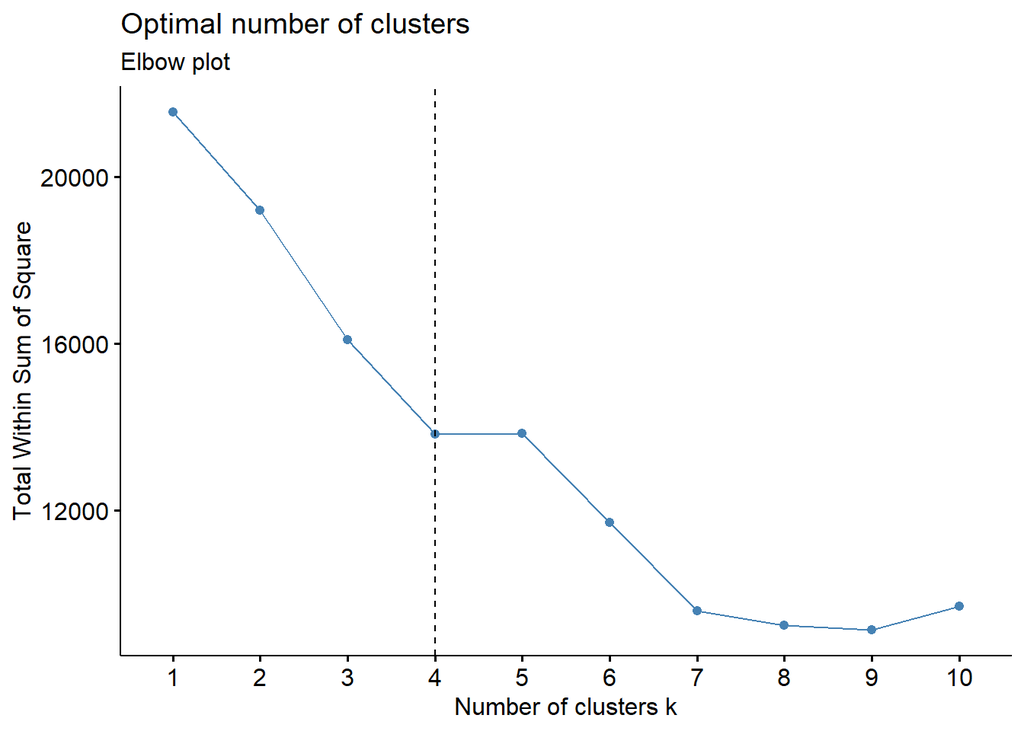

```r
# Using Elbow plot  method, Searching for the optimal number of clusters
fviz_nbclust(df_norm, kmeans, method = "wss") +
    geom_vline(xintercept = 4, linetype = 2)+
  labs(subtitle = "Elbow plot")
```

```r
# Compute k-means clustering with k = 4
set.seed(123)
final <- kmeans(df_norm, 4, nstart = 25)
print(final)
```

```
## K-means clustering with 4 clusters of sizes 2607, 4515, 2189, 2853
##
## Cluster means:
##   Administrative Administrative_Duration Informational Informational_Duration
## 1     0.07038032              0.01988676    0.01681371             0.01004575
## 2     0.08817522              0.02443834    0.01989664             0.01355229
## 3     0.09720319              0.02683643    0.02512563             0.01536849
## 4     0.09211876              0.02532751    0.02452097             0.01601592
##   ProductRelated ProductRelated_Duration BounceRates ExitRates PageValues
## 1     0.03682230              0.01508009  0.13038712 0.2437403 0.01431690
## 2     0.04053282              0.01695680  0.09212228 0.2016800 0.01565459
## 3     0.06455877              0.02726596  0.09792094 0.1956149 0.01956196
## 4     0.04709140              0.01917252  0.08632375 0.1838577 0.01748962
##    SpecialDay   MonthAug  MonthDec    MonthFeb   MonthJul  MonthJune  MonthMar
## 1 0.216340621 0.00000000 0.0000000 0.000000000 0.00000000 0.00000000 0.0000000
```

[output cut: 1901 more lines]

```r
# Previewing the number of records in each cluster

final$size
```

```
## [1] 2607 4515 2189 2853
```

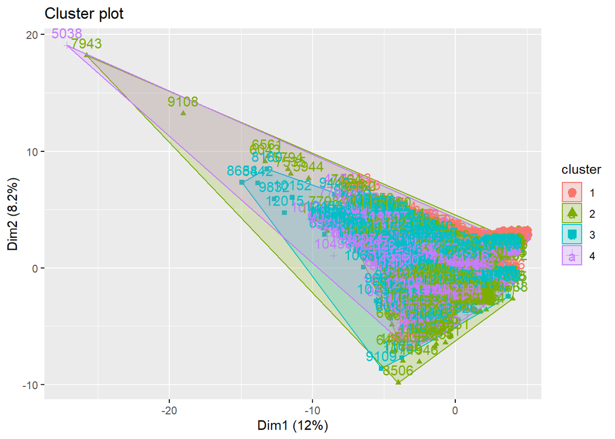

```r
# visualize the results
fviz_cluster(final, data = df)
```

The visualization isn’t really clear.

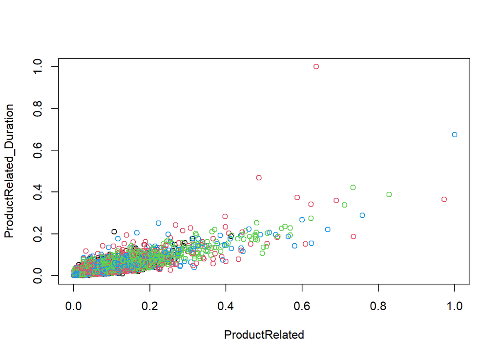

```r
# Plotting two variables to see how their data points have been distributed in the cluster
# Product Related, vs Product Related Duration

plot(df_norm[, 5:6], col = final$cluster)
```

Extract the clusters and add to our initial data to do some descriptive statistics at the cluster level

```r
shop %>%
  mutate(Cluster = final$cluster) %>%
  group_by(Cluster) %>%
  summarise_all("mean")
```

| Cluster | Administrative | Administrative_Duration | Informational | Informational_Duration | ProductRelated | ProductRelated_Duration | BounceRates | ExitRates | PageValues | SpecialDay | Month | OperatingSystems | Browser | Region | TrafficType | VisitorType | Weekend | Revenue |
| --- | --- | --- | --- | --- | --- | --- | --- | --- | --- | --- | --- | --- | --- | --- | --- | --- | --- | --- |
| 1 | 1.900269 | 67.59011 | 0.4035290 | 25.61037 | 25.95972 | 964.7266 | 0.02607742 | 0.04874805 | 5.179336 | 0.216340621 | NA | 2.140008 | 2.405830 | 3.115458 | 4.518987 | NA | 0 | 0.1020330 |
| 2 | 2.380731 | 83.05981 | 0.4775194 | 34.54987 | 28.57564 | 1084.7861 | 0.01842446 | 0.04033599 | 5.663264 | 0.006998893 | NA | 2.122038 | 2.457143 | 3.241196 | 3.719823 | NA | 0 | 0.1313400 |
| 3 | 2.624486 | 91.21031 | 0.6030151 | 39.18003 | 45.51393 | 1744.2997 | 0.01958419 | 0.03912298 | 7.076808 | 0.000000000 | NA | 2.106441 | 2.253084 | 3.022385 | 4.308360 | NA | 0 | 0.2512563 |
| 4 | 2.487206 | 86.08189 | 0.5885033 | 40.83059 | 33.19944 | 1226.5335 | 0.01726475 | 0.03677154 | 6.327112 | 0.055660708 | NA | 2.128286 | 2.236243 | 3.146512 | 4.057483 | NA | 1 | 0.1749036 |